# Chapter 5 MANOVA

# Multivariate Regression

Multiple regression models are used to establish the relationship between a dependent variable (i.e. an outcome of interest) and more than 1 independent variable. Multivariate regression can be used to establish the relationship between more than 1 dependent variable and some independent variable(s).

Multivariate linear model: $$ \begin{align} \mathbf{Y}=\mathbf{B}^T\mathbf{X}+\boldsymbol{\varepsilon} \end{align} $$

where $\mathbf{Y}=(Y_1,\ldots,Y_q)^T$, $\mathbf{X}=(X_1,\ldots,X_p)^T$ , $\boldsymbol{\varepsilon}:=(\varepsilon_1,\ldots,\varepsilon_q)^T$ and $$ \begin{align*} \mathbf{B}=\begin{pmatrix} \beta_{11} & \ldots & \beta_{1q} \\ \vdots & \ddots & \vdots \\ \beta_{p1} & \ldots & \beta_{pq} \end{pmatrix}_{p\times q}. \end{align*} $$

$$ \begin{align} \begin{pmatrix} Y_{11} & \ldots & Y_{1q} \\ \vdots & \ddots & \vdots \\ Y_{n1} & \ldots & Y_{nq} \end{pmatrix}_{n\times q}\!\!\! &= \begin{pmatrix} X_{11} & \ldots & X_{1p} \\ \vdots & \ddots & \vdots \\ X_{n1} & \ldots & X_{np} \end{pmatrix}_{n\times p} \begin{pmatrix} \beta_{11} & \ldots & \beta_{1q} \\ \vdots & \ddots & \vdots \\ \beta_{p1} & \ldots & \beta_{pq} \end{pmatrix}_{p\times q}\!\!\! + \begin{pmatrix} \varepsilon_{11} & \ldots & \varepsilon_{1q} \\ \vdots & \ddots & \vdots \\ \varepsilon_{n1} & \ldots & \varepsilon_{nq} \end{pmatrix}_{n\times q}, \end{align} $$

When $q = 1$, and $p>1$ it is a multiple regression.

### The underlying assumptions:

1. **Linearity**  
   Each predictor should have a linear relationship with each outcome. Nonlinear relationships can bias the results.
2. **Independence**  
   Observations should be independent. If they are not (e.g., in time-series or clustered data), standard errors may become unreliable.
3. **Multivariate Normality**  
   Error terms are assumed to follow a multivariate normal distribution.
   - Even if this assumption is violated, coefficient estimates remain unbiased.
   - However, confidence intervals and hypothesis tests may lose accuracy.
   - While tests like Shapiro–Wilk can assess normality for individual outcomes, multivariate normality is best evaluated with methods such as **Mardia’s test**, which accounts for correlations among residuals.
4. **Homoscedasticity**  
   The variance of errors should be constant across predictors and outcomes. If not, the model becomes less efficient.
5. **No Multicollinearity issues**  
   Predictors should not be perfectly correlated, as this prevents the model from estimating their separate effects.

Example: Applied Multivariate Statistical Analysis (6th ed.) by Richard Johnson and Dean Wichern. This data come from exercise 7.25 and involve 17 overdoses of the drug amitriptyline (Rudorfer, 1982). There are two responses we want to model: TOT and AMI. TOT is total TCAD plasma level and AMI is the amount of amitriptyline present in the TCAD plasma level.The predictors are:

GEN: gender (male = 0, female = 1)

AMT: amount of drug taken at the time of overdose

PR: PR wave measurement

DIAP: diastolic blood pressure

QRS: QRS wave measurement

The purpose is to build a regression model using other variables to predict tot and ami. In the problem, there are two responses (multivariate).

```r
library(BNSP)
data(ami)

head(ami)
```

A data.frame: 6 × 7

|  | tot <int> | ami <int> | gen <int> | amt <int> | pr <int> | bp <int> | qrs <int> |
| --- | --- | --- | --- | --- | --- | --- | --- |
| 1 | 3389 | 3149 | 1 | 7500 | 220 | 0 | 140 |
| 2 | 1101 | 653 | 1 | 1975 | 200 | 0 | 100 |
| 3 | 1131 | 810 | 0 | 3600 | 205 | 60 | 111 |
| 4 | 596 | 448 | 1 | 675 | 160 | 60 | 120 |
| 5 | 896 | 844 | 1 | 750 | 185 | 70 | 83 |
| 6 | 1767 | 1450 | 1 | 2500 | 180 | 60 | 80 |

```r
# The same as the codes for multiple regression , the difference is that the response is multivariate using cbind
fit = lm(cbind(tot, ami)~., data = ami)
fit

summary(fit)
#For estimation of the paramters B,
#the results of multivariate regression are the same as these of multiple regerssion,
#using R least squrares estimate.
fit.tot = lm(tot~ gen+amt+pr+bp + qrs , data = ami)
fit.tot
summary(fit.tot)

summary(fit, test = "Pillai")
summary(fit, test = "Wilks")

#For hypothesis testing, confidence intervals, ....
#We can not use several multiple regression for a multivarite regression.
```

[output not shown]

```
Call:
lm(formula = cbind(tot, ami) ~ ., data = ami)

Coefficients:
             tot         ami
(Intercept)  -2879.4782  -2728.7085
gen            675.6508    763.0298
amt              0.2849      0.3064
pr              10.2721      8.8962
bp               7.2512      7.2056
qrs              7.5982      4.9871
```

```
Response tot :

Call:
lm(formula = tot ~ gen + amt + pr + bp + qrs, data = ami)

Residuals:
   Min     1Q Median     3Q    Max
-399.2 -180.1    4.5  164.1  366.8

Coefficients:
              Estimate Std. Error t value Pr(>|t|)
(Intercept) -2.879e+03  8.933e+02  -3.224 0.008108 **
gen          6.757e+02  1.621e+02   4.169 0.001565 **
amt          2.848e-01  6.091e-02   4.677 0.000675 ***
pr           1.027e+01  4.255e+00   2.414 0.034358 *
bp           7.251e+00  3.225e+00   2.248 0.046026 *
qrs          7.598e+00  3.849e+00   1.974 0.074006 .
---
Signif. codes:  0 ‘***’ 0.001 ‘**’ 0.01 ‘*’ 0.05 ‘.’ 0.1 ‘ ’ 1

Residual standard error: 281.2 on 11 degrees of freedom
Multiple R-squared:  0.8871,	Adjusted R-squared:  0.8358
F-statistic: 17.29 on 5 and 11 DF,  p-value: 6.983e-05


Response ami :

Call:
lm(formula = ami ~ gen + amt + pr + bp + qrs, data = ami)

Residuals:
    Min      1Q  Median      3Q     Max
-373.85 -247.29  -83.74  217.13  462.72

Coefficients:
              Estimate Std. Error t value Pr(>|t|)
(Intercept) -2.729e+03  9.288e+02  -2.938 0.013502 *
gen          7.630e+02  1.685e+02   4.528 0.000861 ***
amt          3.064e-01  6.334e-02   4.837 0.000521 ***
pr           8.896e+00  4.424e+00   2.011 0.069515 .
bp           7.206e+00  3.354e+00   2.149 0.054782 .
qrs          4.987e+00  4.002e+00   1.246 0.238622
---
Signif. codes:  0 ‘***’ 0.001 ‘**’ 0.01 ‘*’ 0.05 ‘.’ 0.1 ‘ ’ 1

Residual standard error: 292.4 on 11 degrees of freedom
Multiple R-squared:  0.8764,	Adjusted R-squared:  0.8202
F-statistic:  15.6 on 5 and 11 DF,  p-value: 0.0001132
```

```
Call:
lm(formula = tot ~ gen + amt + pr + bp + qrs, data = ami)

Coefficients:
(Intercept)          gen          amt           pr           bp          qrs
 -2879.4782     675.6508       0.2849      10.2721       7.2512       7.5982
```

```
Call:
lm(formula = tot ~ gen + amt + pr + bp + qrs, data = ami)

Residuals:
   Min     1Q Median     3Q    Max
-399.2 -180.1    4.5  164.1  366.8

Coefficients:
              Estimate Std. Error t value Pr(>|t|)
(Intercept) -2.879e+03  8.933e+02  -3.224 0.008108 **
gen          6.757e+02  1.621e+02   4.169 0.001565 **
amt          2.848e-01  6.091e-02   4.677 0.000675 ***
pr           1.027e+01  4.255e+00   2.414 0.034358 *
bp           7.251e+00  3.225e+00   2.248 0.046026 *
qrs          7.598e+00  3.849e+00   1.974 0.074006 .
---
Signif. codes:  0 ‘***’ 0.001 ‘**’ 0.01 ‘*’ 0.05 ‘.’ 0.1 ‘ ’ 1

Residual standard error: 281.2 on 11 degrees of freedom
Multiple R-squared:  0.8871,	Adjusted R-squared:  0.8358
F-statistic: 17.29 on 5 and 11 DF,  p-value: 6.983e-05
```

### 1. Multivariate Model for `tot` and `ami`:

$$ \begin{bmatrix} \hat{tot} \\ \hat{ami} \end{bmatrix} = \begin{bmatrix} -2879.48 \\ -2728.71 \end{bmatrix} + \begin{bmatrix} 675.65 \\ 763.03 \end{bmatrix} \cdot \text{gen} + \begin{bmatrix} 0.28 \\ 0.31 \end{bmatrix} \cdot \text{amt} + \begin{bmatrix} 10.27 \\ 8.90 \end{bmatrix} \cdot \text{pr} + \begin{bmatrix} 7.25 \\ 7.21 \end{bmatrix} \cdot \text{bp} + \begin{bmatrix} 7.60 \\ 4.99 \end{bmatrix} \cdot \text{qrs} $$

### 2. Univariate Linear Model for `tot`:

$$ \hat{tot} = -2879.48 + 675.65 \cdot \text{gen} + 0.28 \cdot \text{amt} + 10.27 \cdot \text{pr} + 7.25 \cdot \text{bp} + 7.60 \cdot \text{qrs} $$

### 3. Univariate Linear Model for `ami`:

$$ \hat{ami} = -2728.71 + 763.03 \cdot \text{gen} + 0.31 \cdot \text{amt} + 8.90 \cdot \text{pr} + 7.21 \cdot \text{bp} + 4.99 \cdot \text{qrs} $$

We also express the multivariate regression model in matrix form as:

The fitted model:

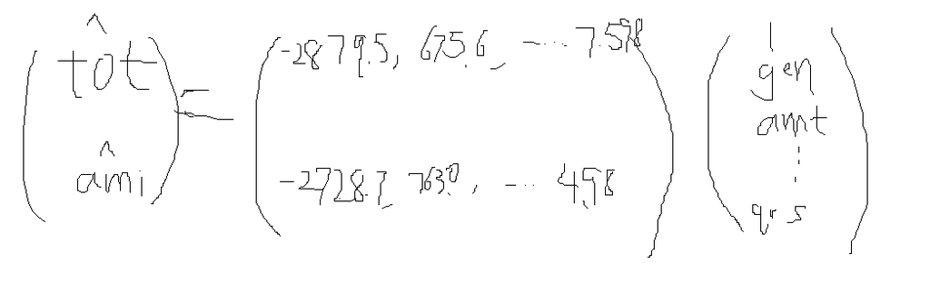

Excerise: mtcars dataset:

To predict both Miles Per Gallon (mpg) and Horsepower (hp) simultaneously, using predictors such as number of cylinders (cyl), weight (wt), and transmission type (am). Please provide the fitted model.